# (Exploration of Loan Dataset from Prosper)

## by Emad Tolba Elshahat Muhammad

## Preliminary Wrangling

> The data set is downloaded from [this link](https://s3.amazonaws.com/udacity-hosted-downloads/ud651/prosperLoanData.csv), and contains 113,937 loans with 81 variables on each loan, including loan amount, borrower rate (or interest rate), current loan status, borrower income, and many others.Prosper is company located in a San Francisco, California specialized in loans at low interest rates to the borrowers.

> This [data dictionary](https://docs.google.com/spreadsheets/d/1gDyi_L4UvIrLTEC6Wri5nbaMmkGmLQBk-Yx3z0XDEtI/edit#gid=0) explains all variables in the data set.

```python
# import all packages and set plots to be embedded inline
import numpy as np
import pandas as pd
import matplotlib.pyplot as plt
import seaborn as sb

%matplotlib inline
```

```python
#loading the dataset
data= pd.read_csv('prosperLoanData.csv')
data.head()
```

|  | ListingKey | ListingNumber | ListingCreationDate | CreditGrade | Term | LoanStatus | ClosedDate | BorrowerAPR | BorrowerRate | LenderYield | ... | LP_ServiceFees | LP_CollectionFees | LP_GrossPrincipalLoss | LP_NetPrincipalLoss | LP_NonPrincipalRecoverypayments | PercentFunded | Recommendations | InvestmentFromFriendsCount | InvestmentFromFriendsAmount | Investors |
| --- | --- | --- | --- | --- | --- | --- | --- | --- | --- | --- | --- | --- | --- | --- | --- | --- | --- | --- | --- | --- | --- |
| 0 | 1021339766868145413AB3B | 193129 | 2007-08-26 19:09:29.263000000 | C | 36 | Completed | 2009-08-14 00:00:00 | 0.16516 | 0.1580 | 0.1380 | ... | -133.18 | 0.0 | 0.0 | 0.0 | 0.0 | 1.0 | 0 | 0 | 0.0 | 258 |
| 1 | 10273602499503308B223C1 | 1209647 | 2014-02-27 08:28:07.900000000 | NaN | 36 | Current | NaN | 0.12016 | 0.0920 | 0.0820 | ... | 0.00 | 0.0 | 0.0 | 0.0 | 0.0 | 1.0 | 0 | 0 | 0.0 | 1 |
| 2 | 0EE9337825851032864889A | 81716 | 2007-01-05 15:00:47.090000000 | HR | 36 | Completed | 2009-12-17 00:00:00 | 0.28269 | 0.2750 | 0.2400 | ... | -24.20 | 0.0 | 0.0 | 0.0 | 0.0 | 1.0 | 0 | 0 | 0.0 | 41 |
| 3 | 0EF5356002482715299901A | 658116 | 2012-10-22 11:02:35.010000000 | NaN | 36 | Current | NaN | 0.12528 | 0.0974 | 0.0874 | ... | -108.01 | 0.0 | 0.0 | 0.0 | 0.0 | 1.0 | 0 | 0 | 0.0 | 158 |
| 4 | 0F023589499656230C5E3E2 | 909464 | 2013-09-14 18:38:39.097000000 | NaN | 36 | Current | NaN | 0.24614 | 0.2085 | 0.1985 | ... | -60.27 | 0.0 | 0.0 | 0.0 | 0.0 | 1.0 | 0 | 0 | 0.0 | 20 |

5 rows × 81 columns

```python
data.shape
```

```
(113937, 81)
```

```python
data.info()
```

```
<class 'pandas.core.frame.DataFrame'>
RangeIndex: 113937 entries, 0 to 113936
Data columns (total 81 columns):
ListingKey                             113937 non-null object
ListingNumber                          113937 non-null int64
ListingCreationDate                    113937 non-null object
CreditGrade                            28953 non-null object
Term                                   113937 non-null int64
LoanStatus                             113937 non-null object
ClosedDate                             55089 non-null object
BorrowerAPR                            113912 non-null float64
BorrowerRate                           113937 non-null float64
LenderYield                            113937 non-null float64
EstimatedEffectiveYield                84853 non-null float64
EstimatedLoss                          84853 non-null float64
EstimatedReturn                        84853 non-null float64
ProsperRating (numeric)                84853 non-null float64
ProsperRating (Alpha)                  84853 non-null object
ProsperScore                           84853 non-null float64
ListingCategory (numeric)              113937 non-null int64
BorrowerState                          108422 non-null object
Occupation                             110349 non-null object
EmploymentStatus                       111682 non-null object
EmploymentStatusDuration               106312 non-null float64
IsBorrowerHomeowner                    113937 non-null bool
CurrentlyInGroup                       113937 non-null bool
GroupKey                               13341 non-null object
DateCreditPulled                       113937 non-null object
CreditScoreRangeLower                  113346 non-null float64
CreditScoreRangeUpper                  113346 non-null float64
FirstRecordedCreditLine                113240 non-null object
CurrentCreditLines                     106333 non-null float64
OpenCreditLines                        106333 non-null float64
TotalCreditLinespast7years             113240 non-null float64
OpenRevolvingAccounts                  113937 non-null int64
OpenRevolvingMonthlyPayment            113937 non-null float64
InquiriesLast6Months                   113240 non-null float64
TotalInquiries                         112778 non-null float64
CurrentDelinquencies                   113240 non-null float64
AmountDelinquent                       106315 non-null float64
```

[output cut: 31 more lines]

```
LP_CustomerPayments                    113937 non-null float64
LP_CustomerPrincipalPayments           113937 non-null float64
LP_InterestandFees                     113937 non-null float64
LP_ServiceFees                         113937 non-null float64
LP_CollectionFees                      113937 non-null float64
LP_GrossPrincipalLoss                  113937 non-null float64
LP_NetPrincipalLoss                    113937 non-null float64
LP_NonPrincipalRecoverypayments        113937 non-null float64
PercentFunded                          113937 non-null float64
Recommendations                        113937 non-null int64
InvestmentFromFriendsCount             113937 non-null int64
InvestmentFromFriendsAmount            113937 non-null float64
Investors                              113937 non-null int64
dtypes: bool(3), float64(50), int64(11), object(17)
memory usage: 68.1+ MB
```

```python
data.describe()
```

|  | ListingNumber | Term | BorrowerAPR | BorrowerRate | LenderYield | EstimatedEffectiveYield | EstimatedLoss | EstimatedReturn | ProsperRating (numeric) | ProsperScore | ... | LP_ServiceFees | LP_CollectionFees | LP_GrossPrincipalLoss | LP_NetPrincipalLoss | LP_NonPrincipalRecoverypayments | PercentFunded | Recommendations | InvestmentFromFriendsCount | InvestmentFromFriendsAmount | Investors |
| --- | --- | --- | --- | --- | --- | --- | --- | --- | --- | --- | --- | --- | --- | --- | --- | --- | --- | --- | --- | --- | --- |
| count | 1.139370e+05 | 113937.000000 | 113912.000000 | 113937.000000 | 113937.000000 | 84853.000000 | 84853.000000 | 84853.000000 | 84853.000000 | 84853.000000 | ... | 113937.000000 | 113937.000000 | 113937.000000 | 113937.000000 | 113937.000000 | 113937.000000 | 113937.000000 | 113937.000000 | 113937.000000 | 113937.000000 |
| mean | 6.278857e+05 | 40.830248 | 0.218828 | 0.192764 | 0.182701 | 0.168661 | 0.080306 | 0.096068 | 4.072243 | 5.950067 | ... | -54.725641 | -14.242698 | 700.446342 | 681.420499 | 25.142686 | 0.998584 | 0.048027 | 0.023460 | 16.550751 | 80.475228 |
| std | 3.280762e+05 | 10.436212 | 0.080364 | 0.074818 | 0.074516 | 0.068467 | 0.046764 | 0.030403 | 1.673227 | 2.376501 | ... | 60.675425 | 109.232758 | 2388.513831 | 2357.167068 | 275.657937 | 0.017919 | 0.332353 | 0.232412 | 294.545422 | 103.239020 |
| min | 4.000000e+00 | 12.000000 | 0.006530 | 0.000000 | -0.010000 | -0.182700 | 0.004900 | -0.182700 | 1.000000 | 1.000000 | ... | -664.870000 | -9274.750000 | -94.200000 | -954.550000 | 0.000000 | 0.700000 | 0.000000 | 0.000000 | 0.000000 | 1.000000 |
| 25% | 4.009190e+05 | 36.000000 | 0.156290 | 0.134000 | 0.124200 | 0.115670 | 0.042400 | 0.074080 | 3.000000 | 4.000000 | ... | -73.180000 | 0.000000 | 0.000000 | 0.000000 | 0.000000 | 1.000000 | 0.000000 | 0.000000 | 0.000000 | 2.000000 |
| 50% | 6.005540e+05 | 36.000000 | 0.209760 | 0.184000 | 0.173000 | 0.161500 | 0.072400 | 0.091700 | 4.000000 | 6.000000 | ... | -34.440000 | 0.000000 | 0.000000 | 0.000000 | 0.000000 | 1.000000 | 0.000000 | 0.000000 | 0.000000 | 44.000000 |
| 75% | 8.926340e+05 | 36.000000 | 0.283810 | 0.250000 | 0.240000 | 0.224300 | 0.112000 | 0.116600 | 5.000000 | 8.000000 | ... | -13.920000 | 0.000000 | 0.000000 | 0.000000 | 0.000000 | 1.000000 | 0.000000 | 0.000000 | 0.000000 | 115.000000 |
| max | 1.255725e+06 | 60.000000 | 0.512290 | 0.497500 | 0.492500 | 0.319900 | 0.366000 | 0.283700 | 7.000000 | 11.000000 | ... | 32.060000 | 0.000000 | 25000.000000 | 25000.000000 | 21117.900000 | 1.012500 | 39.000000 | 33.000000 | 25000.000000 | 1189.000000 |

8 rows × 61 columns

```python
# Check of duplicated data rows
data.duplicated().sum()
```

```
0
```

```python
# Selecting feature of interest and related features
selected_features = ['Term','LoanStatus','BorrowerAPR', 'ProsperScore', 'BorrowerState',
                     'EmploymentStatus', 'CreditScoreRangeUpper', 'LoanOriginalAmount',
                     'AvailableBankcardCredit', 'StatedMonthlyIncome' ]
data = data[selected_features]
data.info()
```

```
<class 'pandas.core.frame.DataFrame'>
RangeIndex: 113937 entries, 0 to 113936
Data columns (total 10 columns):
Term                       113937 non-null int64
LoanStatus                 113937 non-null object
BorrowerAPR                113912 non-null float64
ProsperScore               84853 non-null float64
BorrowerState              108422 non-null object
EmploymentStatus           111682 non-null object
CreditScoreRangeUpper      113346 non-null float64
LoanOriginalAmount         113937 non-null int64
AvailableBankcardCredit    106393 non-null float64
StatedMonthlyIncome        113937 non-null float64
dtypes: float64(5), int64(2), object(3)
memory usage: 8.7+ MB
```

```python
# Removing null values
data.dropna(inplace = True)
data.isnull().sum()
```

```
Term                       0
LoanStatus                 0
BorrowerAPR                0
ProsperScore               0
BorrowerState              0
EmploymentStatus           0
CreditScoreRangeUpper      0
LoanOriginalAmount         0
AvailableBankcardCredit    0
StatedMonthlyIncome        0
dtype: int64
```

```python
data.shape
```

```
(84853, 10)
```

### What is the structure of your dataset?

> The dataset has 113937 rows of loans entries and 81 features(columns). Each loan contain information on the borrowered's background information and details regarding the loans. We selecting only 10 features(columns) for investegation and after dropping Null values the data will contains 84853 loans entries.

### What is/are the main feature(s) of interest in your dataset?

> The main feature of interest is LoanStatus(loan’s outcome status). we will investigate what factors affect a loan’s outcome status?

### What feature in the dataset do you think will help support your investigation into your feature(s) of interest?

> - Term
> - LoanStatus
> - BorrowerAPR
> - ProsperScore
> - BorrowerState
> - EmploymentStatus
> - CreditScoreRangeUpper
> - LoanOriginalAmount
> - AvailableBankcardCredit
> - StatedMonthlyIncome

## Univariate Exploration

> In this section, investigate distributions of individual variables.

### 1- Analysis of Loan Status variable:

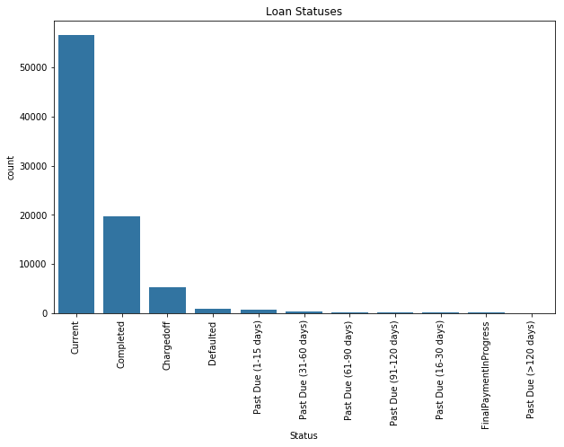

```python
# Check Loan Status
plt.figure(figsize=[10,6])
order = data['LoanStatus'].value_counts().index
color= sb.color_palette()[0]
sb.countplot(data = data, x='LoanStatus', color=color, order =order)
plt.xticks(rotation=90)
plt.title('Loan Statuses')
plt.xlabel('Status')
plt.ylabel('count')
```

> **Current status is the highest count followed by Completed. Chargedoff and Defaulted.**

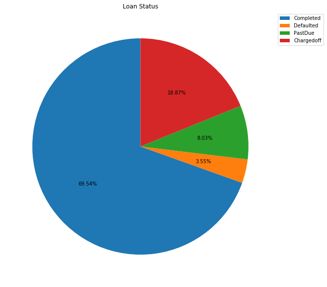

```python
#  Pie chart for Loan status excluding the loans with status Current
Completed = data[data['LoanStatus']== 'Completed'].shape[0]
Defaulted = data[data['LoanStatus']== 'Defaulted'].shape[0]
PastDue = data[(data['LoanStatus'] == 'Past Due (1-15 days)') |
                 (data['LoanStatus'] == 'Past Due (31-60 days)') |
                 (data['LoanStatus'] == 'Past Due (61-90 days)') |
                 (data['LoanStatus'] == 'Past Due (91-120 days)') |
                 (data['LoanStatus'] == 'Past Due (16-30 days)') |
                 (data['LoanStatus'] == 'FinalPaymentInProgress') |
                 (data['LoanStatus'] == 'Past Due (>120 days)')].shape[0]
Chargedoff = data[data['LoanStatus']== 'Chargedoff'].shape[0]

plt.figure(figsize=[10,10])
loan_status_without_current = [Completed, Defaulted, PastDue, Chargedoff ]
labels = [ 'Completed', 'Defaulted', 'PastDue', 'Chargedoff']
plt.pie(loan_status_without_current , startangle = 90, autopct='%1.2f%%')
plt.title('Loan Status')
plt.legend(labels, loc="best", bbox_to_anchor=(1,1));
```

> **After excluding the loans with status Current, there are 69.54% loans with status 'Completed', 3.55% with status 'Defaulted', 8.03% with status 'PastDue' and 18.87% with status 'Chargedoff'.**

### 2- Analysis of number of loans per state (BorrowerState):

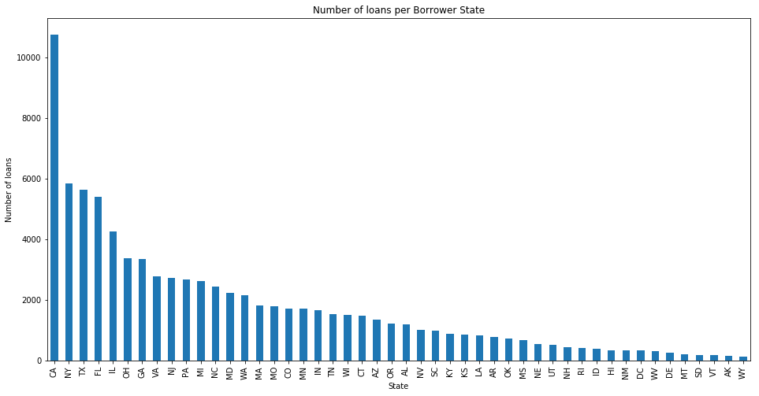

```python
color = sb.color_palette()[0]
plt.figure(figsize=(16, 8))
data.BorrowerState.value_counts().plot(kind='bar', color=color)
plt.title('Number of loans per Borrower State')
plt.xlabel('State')
plt.ylabel('Number of loans')
plt.xticks(rotation=90);
```

> **The highest number of loans in CA, NY, TX, FL and IL. and the least in VT, AK. WY**

### 3- Analysis of ProsperScore:

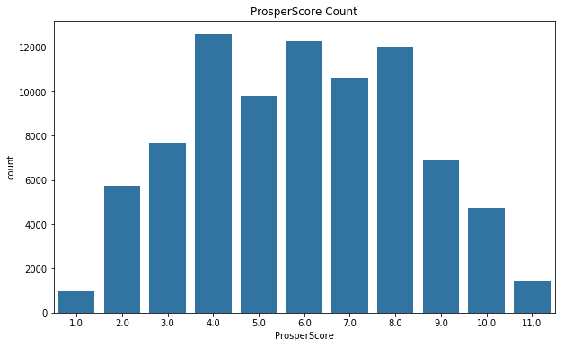

```python
# Countplot
color= sb.color_palette()[0]
plt.figure(figsize=[10,6])
sb.countplot(data = data, x='ProsperScore', color=color)
plt.title('ProsperScore Count')
plt.xlabel('ProsperScore')
plt.ylabel('count');
```

### 4- Analysis of Employment Status variable:

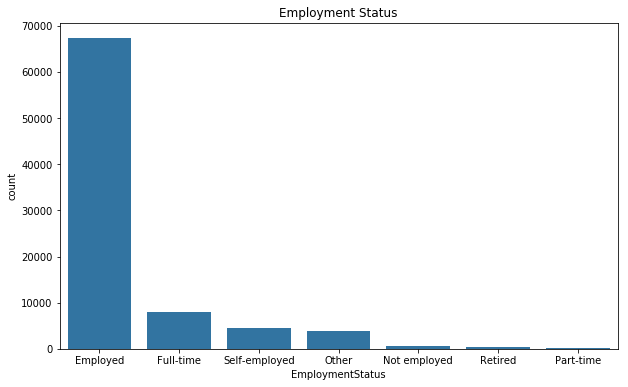

```python
# Countplot
plt.figure(figsize=[10,6])
order = data['EmploymentStatus'].value_counts().index
color= sb.color_palette()[0]
sb.countplot(data = data, x= 'EmploymentStatus', order = order, color = color)
plt.title('Employment Status');
```

> **most of the borrowers are Employed and Full-time employed. Other Employment Status are very low count.**

### 5- Analysis Term variable (the length of the loan expressed in months):

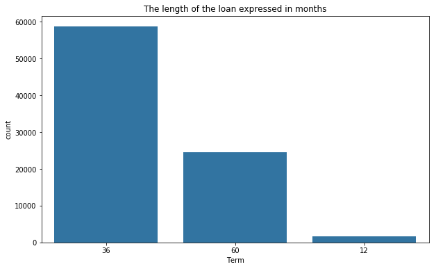

```python
# Countplot
plt.figure(figsize=[10,6])
order = data['Term'].value_counts().index
color= sb.color_palette()[0]
sb.countplot(data = data, x= 'Term', order = order, color = color)
plt.title('The length of the loan expressed in months');
```

> **Most loans are 36 month terms followed by 60 month and 12 month**

### 6- Analysis of The Borrower’s Annual Percentage Rate (BorrowerAPR):

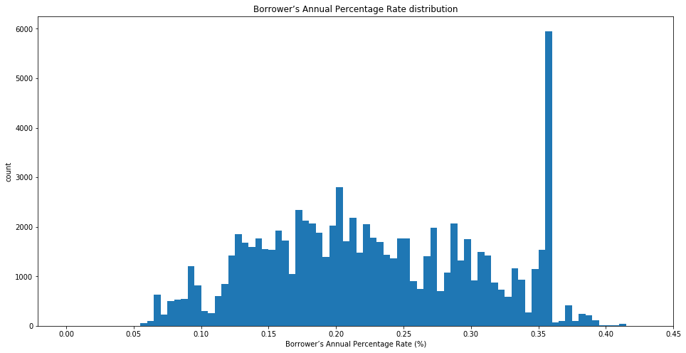

```python
#histogram plot
bins = np.arange(0, data['BorrowerAPR'].max(), 0.005)
plt.figure(figsize=(16, 8))
plt.hist(data =  data, x= 'BorrowerAPR', bins = bins)
plt.title('Borrower’s Annual Percentage Rate distribution')
plt.xlabel('Borrower’s Annual Percentage Rate (%)')
plt.ylabel('count')
plt.xticks(np.arange(0, data['BorrowerAPR'].max()+0.05, 0.05));
```

> **Borrower’s Annual Percentage Rate (APR) is roughly normal distribution with exceptional high count at BorrowerAPR about 0.36 %.**

### 7- Analysis of StatedMonthlyIncome:

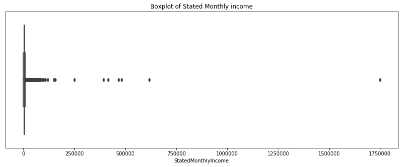

```python
# Box plot Stated Monthly Income to show the outliers
plt.figure(figsize=[14,5])
sb.boxplot(x = data['StatedMonthlyIncome'])
plt.title('Boxplot of Stated Monthly income');
```

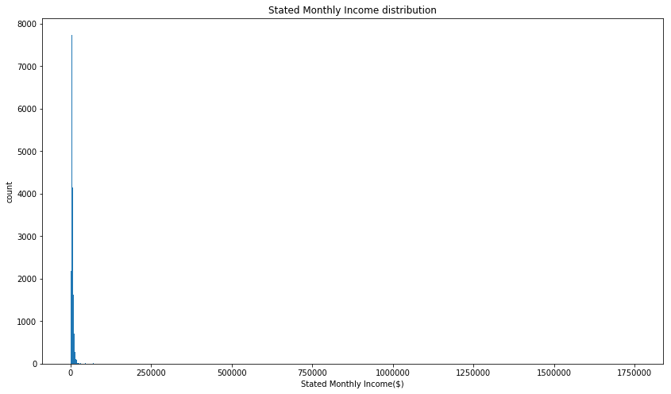

```python
# Plot histogram of all data
bins = np.arange(0, data['StatedMonthlyIncome'].max(), 500)
plt.figure(figsize=(14, 8))
plt.hist(data =  data, x= 'StatedMonthlyIncome', bins = bins)
plt.title('Stated Monthly Income distribution')
plt.xlabel('Stated Monthly Income($)')
plt.ylabel('count');
```

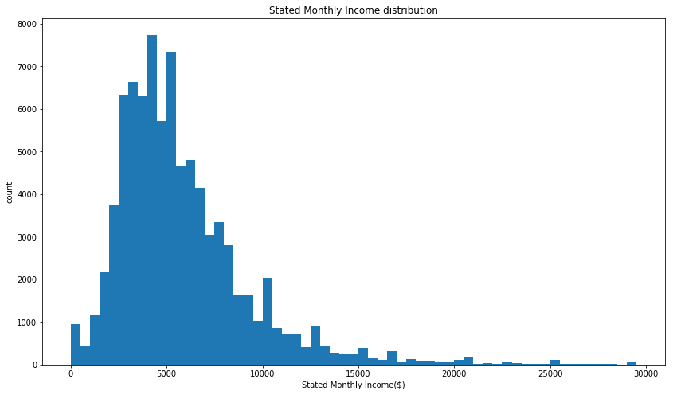

```python
# Plot histogram of Monthly Income between 0 and 30000
bins = np.arange(0, 30000, 500)
plt.figure(figsize=(14, 8))
plt.hist(data =  data, x= 'StatedMonthlyIncome', bins = bins)
plt.title('Stated Monthly Income distribution')
plt.xlabel('Stated Monthly Income($)')
plt.ylabel('count');
```

> **The distribution of Stated Monthly Income is severe right skewed due to the outliers which are presented with the high incomes. The most Monthly Income is between 0 and 20000.**

### 8- Analysis of CreditScoreRangeUpper Variable:

```python
print(data['CreditScoreRangeUpper'].max())
print(data['CreditScoreRangeUpper'].min())
```

```
899.0
619.0
```

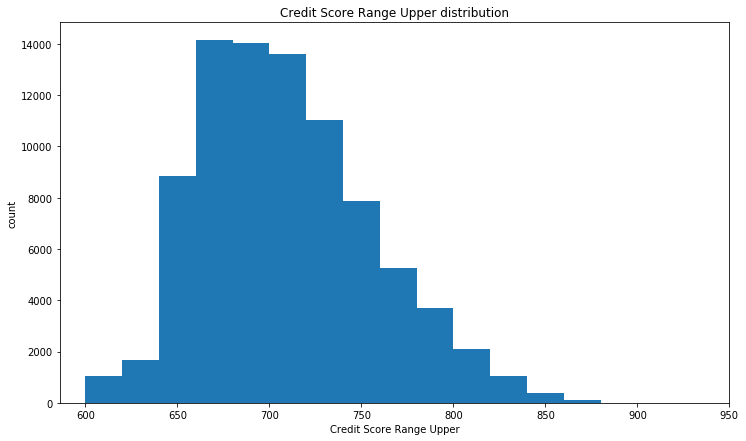

```python
# Histogram ploting
bins = np.arange(600, data['CreditScoreRangeUpper'].max(), 20)
plt.figure(figsize=(12, 7))
plt.hist(data =  data, x= 'CreditScoreRangeUpper', bins = bins)
plt.title('Credit Score Range Upper distribution')
plt.xticks(np.arange(600, 1000, 50))
plt.xlabel('Credit Score Range Upper')
plt.ylabel('count');
```

> **Credit Score Range Upper distribution seems to be normal with slightly right skewness.**

### 9- Analysis of Loan Original Amount variable:

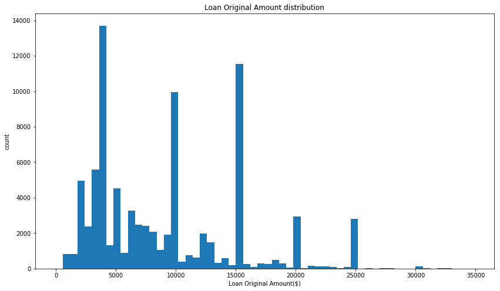

```python
# Histogram ploting
bins = np.arange(0, data['LoanOriginalAmount'].max(), 600)
plt.figure(figsize=(14, 8))
plt.hist(data =  data, x= 'LoanOriginalAmount', bins = bins)
plt.title('Loan Original Amount distribution')
plt.xlabel('Loan Original Amount($)')
plt.ylabel('count');
```

### 10- Analysis of AvailableBankcardCredit:

```python
print(data['AvailableBankcardCredit'].max())
```

```
498374.0
```

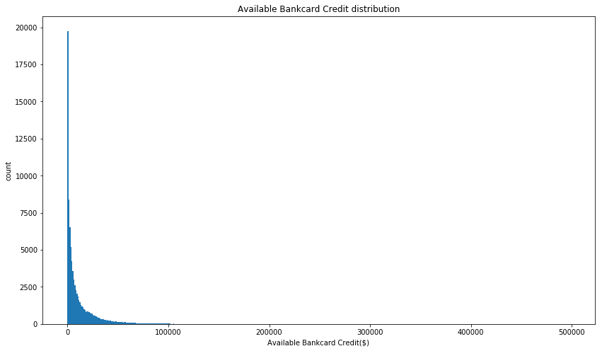

```python
# Histogram ploting
bins = np.arange(0, data['AvailableBankcardCredit'].max(), 1000)
plt.figure(figsize=(14, 8))
plt.hist(data =  data, x= 'AvailableBankcardCredit', bins = bins)
plt.title('Available Bankcard Credit distribution')
plt.xlabel('Available Bankcard Credit($)')
plt.ylabel('count');
```

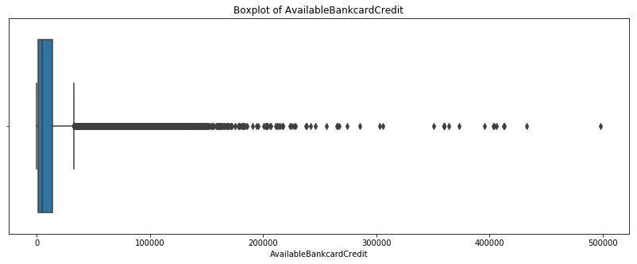

```python
# Box plot AvailableBankcardCredit to show the outliers
plt.figure(figsize=[14,5])
sb.boxplot(x = data['AvailableBankcardCredit'])
plt.title('Boxplot of AvailableBankcardCredit');
```

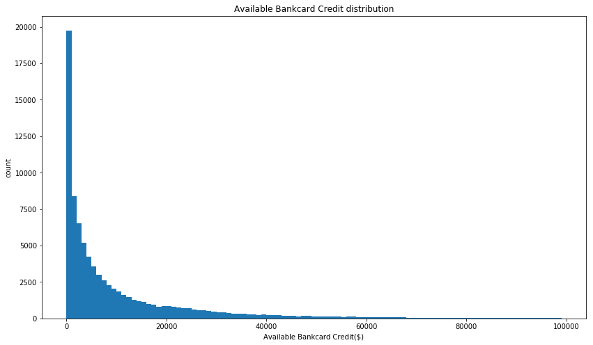

```python
# Plot histogram of AvailableBankcardCredit between 0 and 100000
bins = np.arange(0, 100000, 1000)
plt.figure(figsize=(14, 8))
plt.hist(data =  data, x= 'AvailableBankcardCredit', bins = bins)
plt.title('Available Bankcard Credit distribution')
plt.xlabel('Available Bankcard Credit($)')
plt.ylabel('count');
```

> **The distribution of AvailableBankcardCredit is severe right skewed due to the outliers which are presented with the high AvailableBankcardCredit. Most customers AvailableBankcardCredit less than 80000.**

### Discuss the distribution(s) of your variable(s) of interest. Were there any unusual points? Did you need to perform any transformations?

> Loan Status variable has very large number of Current loans which was excluded. After excluding the loans with status Current, there are 69.54% loans with status 'Completed', 3.55% with status 'Defaulted', 8.03% with status 'PastDue' and 18.87% with status 'Chargedoff'. So we will filter LoanStatus with the Completed and Defaulted status to investigate what factors affect a loan’s outcome status?

### Of the features you investigated, were there any unusual distributions? Did you perform any operations on the data to tidy, adjust, or change the form of the data? If so, why did you do this?

> - The distribution of Stated Monthly Income is severe right skewed due to the outliers which are presented with the high incomes. The most Monthly Income is between 0 and 20000 so we will filtered them.
> - The distribution of AvailableBankcardCredit is severe right skewed due to the outliers which are presented with the high AvailableBankcardCredit.
> - Most loans are 36 month terms followed by 60 month and the least is 12 month

## Bivariate Exploration

> In this section, investigate relationships between pairs of variables in data.

### 1- Loan Status Vs Stated Monthly Income:

categorical Vs quantitative

```python
# We will filter LoanStatus with the Completed and Defaulted status
# and without outliers for the StatedMonthlyIncome(<=25000)
filterd_data = data[(data['LoanStatus'] == 'Completed') |
                    (data['LoanStatus'] == 'Defaulted')]
filterd_data =filterd_data.loc[filterd_data['StatedMonthlyIncome'] <= 25000]
```

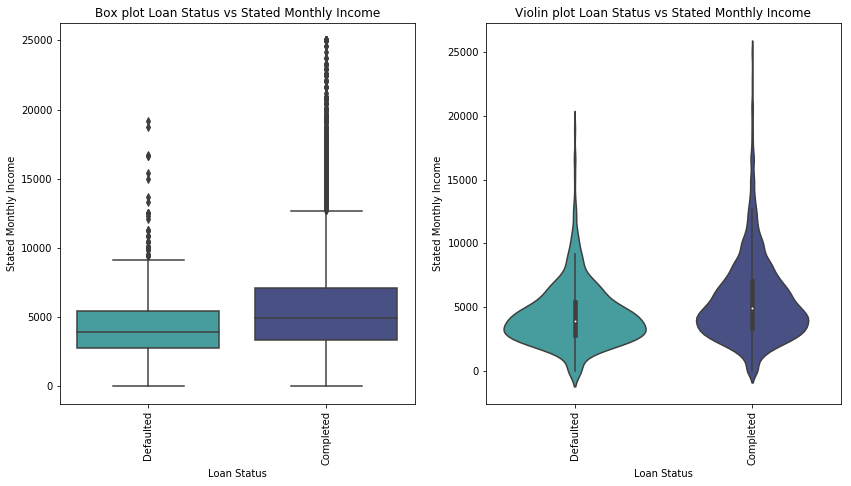

```python
#boxplot for LoanStatus Vs StatedMonthlyIncome
plt.figure(figsize=[14,7])
plt.subplot(1,2,1)
sb.boxplot(data = filterd_data, x='LoanStatus', y='StatedMonthlyIncome', palette = 'mako_r')
plt.title('Box plot Loan Status vs Stated Monthly Income')
plt.ylabel('Stated Monthly Income')
plt.xlabel('Loan Status')
plt.xticks(rotation=90);

#Violinplot for LoanStatus Vs StatedMonthlyIncome
plt.subplot(1,2,2)
sb.violinplot(data = filterd_data, x='LoanStatus', y='StatedMonthlyIncome', palette = 'mako_r')
plt.title('Violin plot Loan Status vs Stated Monthly Income')
plt.ylabel('Stated Monthly Income')
plt.xlabel('Loan Status')
plt.xticks(rotation=90);
```

> - **In box plot the mean of Stated Monthly Income for LoanStatus with the Completed status is slightly higher than that one the Defaulted status.**
> - **In violin plot the Defaulted status is higher for the Stated monthly Income between 2000 and 7000**

### 2- Loan Status Vs Borrower APR:

categorical Vs quantitative

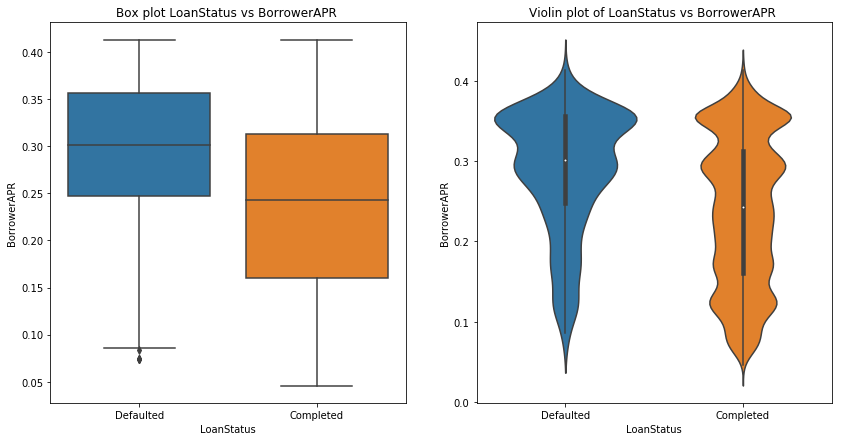

```python
# filter LoanStatus with the Completed and Defaulted status
filterd_data2 = data[(data['LoanStatus'] == 'Completed') |
                    (data['LoanStatus'] == 'Defaulted')]
#Boxplot for LoanStatus vs BorrowerAPR
plt.figure(figsize=[14,7])
plt.subplot(1,2,1)
sb.boxplot(data = filterd_data2, x='LoanStatus', y='BorrowerAPR')
plt.title('Box plot LoanStatus vs BorrowerAPR ')
plt.xlabel('LoanStatus')
plt.ylabel('BorrowerAPR')
#Violinplot for LoanStatus vs BorrowerAPR
plt.subplot(1,2,2)
sb.violinplot(data = filterd_data2, x='LoanStatus', y='BorrowerAPR')
plt.title('Violin plot of LoanStatus vs BorrowerAPR ')
plt.xlabel('LoanStatus')
plt.ylabel('BorrowerAPR');
```

> - **In box plot the mean of Borrower APR for LoanStatus with the Defaulted is higher than that one the Completed status.**
> - **In violin plot the Defaulted status is higher possibility for higher Borrower APR. On the other hand, the Completed cases are evenly distributed for the Borrower APR**

### 3- Loan Status Vs Prosper Score

categorical Vs categorical

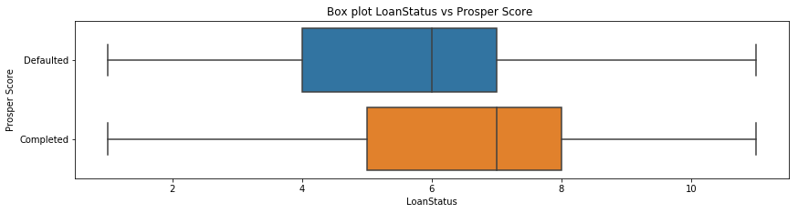

```python
#Boxplot for LoanStatus vs ProsperScore
plt.figure(figsize=[14,7])
plt.subplot(2,1,1)
sb.boxplot(data = filterd_data2, x='ProsperScore', y='LoanStatus')
plt.title('Box plot LoanStatus vs Prosper Score ')
plt.xlabel('LoanStatus')
plt.ylabel('Prosper Score')
```

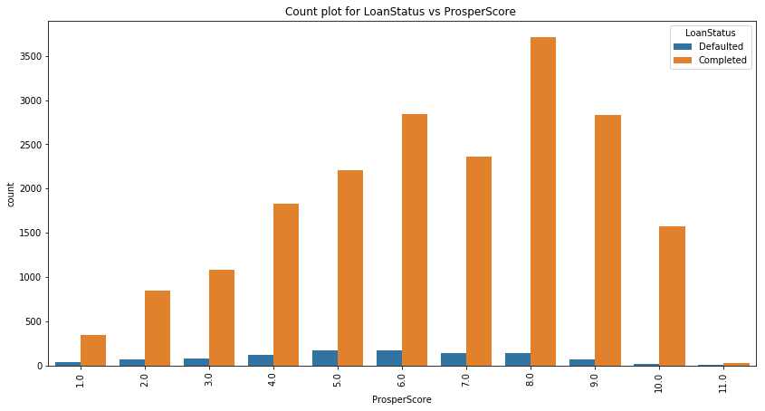

```python
#Countplot for LoanStatus vs ProsperScore
plt.figure(figsize=(14,7))
sb.countplot(x="ProsperScore", hue="LoanStatus", data=filterd_data2)
plt.title('Count plot for LoanStatus vs ProsperScore ')
plt.xticks(rotation=90);
```

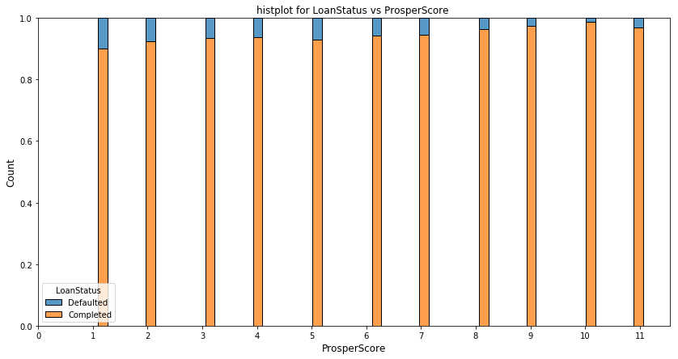

```python
# !pip install seaborn --upgrade (to upgrade seaborn) to use histplot function
# using Histplot for plotting Completed and Defaulted status for each Prosper Score to
#compare between them
plt.figure(figsize=(14,7))
sb.histplot(data=filterd_data2, x="ProsperScore", hue="LoanStatus", stat="probability",
            multiple="fill", shrink=.8)
plt.title('histplot for LoanStatus vs ProsperScore ')
plt.xlabel('ProsperScore', size = 12)
plt.ylabel('Count', size =12)
plt.xticks(np.arange(0, 12, 1));
```

### 4- ProsperScore Vs. BorrowerAPR:

categorical Vs quantitative

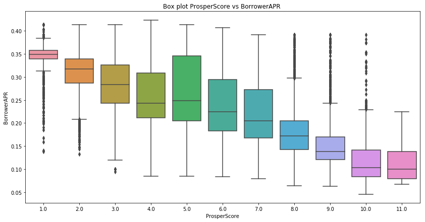

```python
#Boxplot for ProsperScore vs BorrowerAPR
plt.figure(figsize=[14,7])
sb.boxplot(data = data, x='ProsperScore', y='BorrowerAPR')
plt.title('Box plot ProsperScore vs BorrowerAPR ')
plt.xlabel('ProsperScore')
plt.ylabel('BorrowerAPR');
```

> As shown in box plot the mean of Borrower APR for lower Prosper Score is higher than mean of Borrower APR of the higher Prosper Score. As expected small score being highest risky so loans with low score have high Borrower APR . i.e negative correlation.

### 5- CreditScoreRangeUpper Vs. BorrowerAPR:

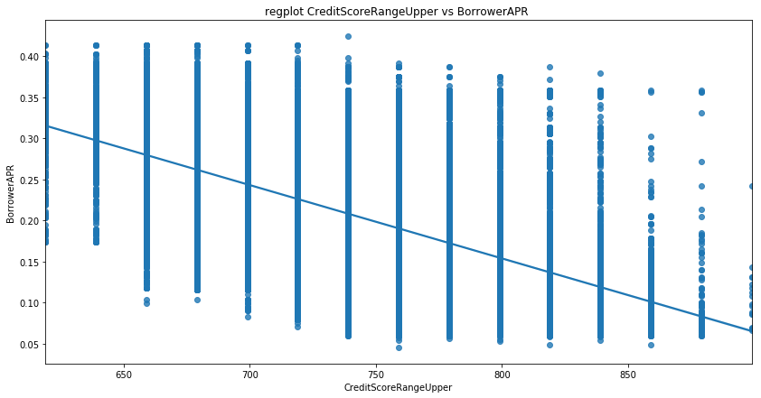

```python
# regplot for CreditScoreRangeUpper Vs. BorrowerAPR
plt.figure(figsize=[14,7])
sb.regplot(data = data, x='CreditScoreRangeUpper', y='BorrowerAPR')
plt.title('regplot CreditScoreRangeUpper vs BorrowerAPR ')
plt.xlabel('CreditScoreRangeUpper')
plt.ylabel('BorrowerAPR');
```

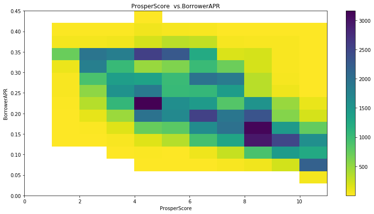

```python
plt.figure(figsize=[14,7])
bins_x = np.arange(0, data['ProsperScore'].max()+1, 1)
bins_y = np.arange(0, data['BorrowerAPR'].max()+0.05, 0.03)
plt.hist2d(data = data, x = 'ProsperScore', y = 'BorrowerAPR', bins = [bins_x, bins_y],
               cmap = 'viridis_r', cmin = 0.5)
plt.colorbar()
plt.title('ProsperScore  vs.BorrowerAPR')
plt.xlabel('ProsperScore')
plt.ylabel('BorrowerAPR');
```

> There are negative correlation between CreditScoreRangeUpper and BorrowerAPR

### 6- LoanOriginalAmount Vs. BorrowerAPR:

numerical Vs numerical

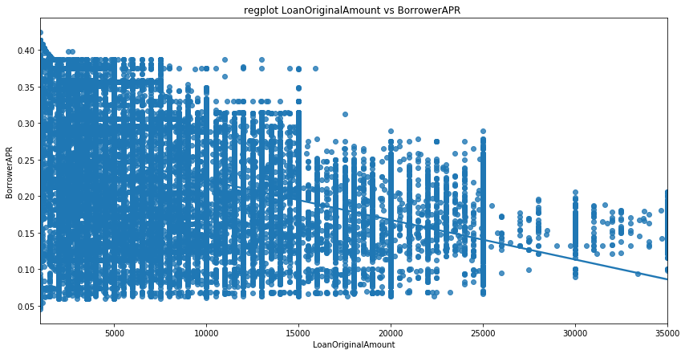

```python
# regplot for CreditScoreRangeUpper Vs. BorrowerAPR
plt.figure(figsize=[14,7])
sb.regplot(data = data, x='LoanOriginalAmount', y='BorrowerAPR')
plt.title('regplot LoanOriginalAmount vs BorrowerAPR ')
plt.xlabel('LoanOriginalAmount')
plt.ylabel('BorrowerAPR');
```

> There are moderate negative correlation between LoanOriginalAmount and BorrowerAPR.

### Did you observe any interesting relationships between the other features (not the main feature(s) of interest)?

> - Loans with lower Prosper Score have higher Borrower APR.
> - There are negative correlation between CreditScoreRangeUpper and BorrowerAPR.
> - There are moderate negative correlation between LoanOriginalAmount and BorrowerAPR.

## Multivariate Exploration

> Create plots of three or more variables to investigate data even further.

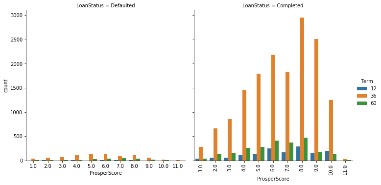

```python
# catplot for ProsperScore Vs Term Vs LoanStatus
plt.figure(figsize=[16,7])
sb.catplot(x="ProsperScore", hue="Term", col="LoanStatus",
                data=filterd_data2, kind="count")
plt.xticks(rotation=90);
```

> - Most loans with Completed LoanStatus are 36 months terms followed by 60 months and the least is 12 months.
> - All the loans with Trem of 12 months are almost Completed

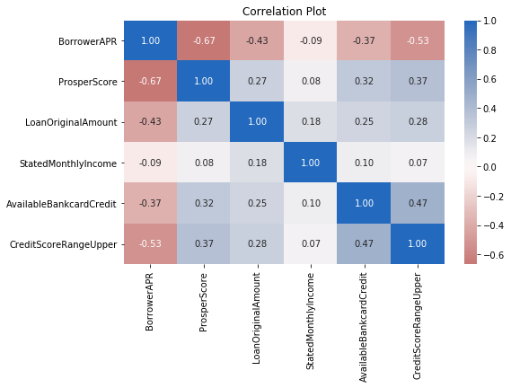

```python
# We can use correlation heat map as multivariables investegation

num_vars = ['BorrowerAPR', 'ProsperScore','LoanOriginalAmount', 'StatedMonthlyIncome',
            'AvailableBankcardCredit', 'CreditScoreRangeUpper']

plt.figure(figsize = [8, 5])
sb.heatmap(data[num_vars].corr(), annot = True, fmt = '.2f',
           cmap = 'vlag_r', center = 0)
plt.title('Correlation Plot')
plt.show()
```

- No strong positive correlation present.
- Positive Correlation between AvailableBankcardCredit And CreditScoreRangeUpper.
- Negative correlation between BorrowerAPR and ProsperScore.
- Negative correlation between BorrowerAPR and CreditScoreRangeUpper.

### Talk about some of the relationships you observed in this part of the investigation. Were there features that strengthened each other in terms of looking at your feature(s) of interest?

> - Most Defaulted LoanStatus are in long Term Loans with 36 months terms followed by 60 months .
> - Almost all loans with Trem of 12 months are Completed Status.

### Were there any interesting or surprising interactions between features?

> No strong positive correlation are present between features. All correlation present are weak to mederate.

### References:

1- https://seaborn.pydata.org/generated/seaborn.catplot.html#seaborn.catplot

2- https://seaborn.pydata.org/index.html

3- https://matplotlib.org/